# 57 Vectors and matrices

This section uses these add-on package:

```julia
using CalculusWithJulia
using Plots
using LinearAlgebra
using SymPy
```

In vectors we introduced the concept of a vector. For `Julia`, vectors are a useful storage container and are used to hold, for example, zeros of functions or the coefficients of a polynomial. Matrices are a two-dimensional version of vector. This section is about the mathematical properties or vectors and matrices.

## 57.1 Vectors

A vector mathematically is a geometric object with two attributes a magnitude and a direction. (The direction is undefined in the case the magnitude is $0$.) Vectors are typically visualized with an arrow, where the anchoring of the arrow is context dependent and is not particular to a given vector.

A point is a position in $R^n$, denoted by $n$ components. Vectors and points are related, but distinct concepts. The two are identified when the tail of the vector is taken to be the origin. Let’s focus on $3$ dimensions. Mathematically, the notation for a point is $p=(x,y,z)$ while the notation for a vector is $\vec{v} = \langle x, y, z \rangle$. The $i$th component in a vector is referenced by a subscript: $v_i$. With this, we may write a typical vector as $\vec{v} = \langle v_1, v_2, \dots, v_n \rangle$ and a vector in $n=3$ as $\vec{v} =\langle v_1, v_2, v_3 \rangle$. The different grouping notation distinguishes the two objects. As another example, the notation $\{x, y, z\}$ indicates a set. While vectors and points may be *identified* by anchoring the vector at the origin. Sets are quite different from both, as the order of their entries is not unique.

`Julia` uses square brackets to group together the components of a vector. The construction `[v1, v2, ..., vn]` creates a `Vector` object:

```julia
[1, 2, 3]
```

```
3-element Vector{Int64}:
 1
 2
 3
```

(The type of the elements is also indicated.)

We have seen that `Plots` interprets tuples as points. We can use tuples as points, though it can be a bit cumbersome as certain arithmetic operations aren’t defined for tuples. As such, we often use a vector to indicate a point or a vector, leaving the interpretation to the reader.

The square bracket constructor has some subtleties:

- `[x, y, z]` calls `Base.vect` and creates a 1-dimensional array or vector.
- `[x; y; z]` calls `vcat` to **v**ertically con**cat**enate values together. With simple (scalar) values `[x, y, z]` and `[x; y; z]` are identical, but not in other cases. (For example, if `A` is a matrix then `[A, A]` is a vector of matrices, `[A; A]` is a matrix combined from the two pieces.
- `[x y z]` calls `hcat` to **h**orizontally con**cat**enate values together. If `x`, `y` are numbers then `[x y]` is *not* a vector, but rather a $2$D array with a single row and two columns.
- finally `[w x; y z]` calls `hvcat` to horizontally and vertically concatenate values together to create a container in two dimensions, like a matrix.

(A vector, mathematically, is a one-dimensional collection of numbers, a matrix a two-dimensional *rectangular* collection of numbers, and an array an $n$-dimensional rectangular-like collection of numbers. In `Julia` the `Array` type is a general type to hold *homogeneous* data along different dimensions. The `Vector` type is an array specialized to one dimension; the `Matrix` type is a specialization to two dimensions.)

### 57.1.1 Vector addition

As seen earlier, vectors have some arithmetic operations defined for them. As a typical use of vectors, mathematically, is to collect the $x$, $y$, and $z$ (in $3$D) components together, operations like addition and subtraction operate component wise.

**NoteVector addition**

$$\langle a_1, a_2, \dots, a_n \rangle +
\langle b_1, b_2, \dots, b_n \rangle =
\langle (a_1 + b_1), (a_2 + b_2), \dots, (a_n + b_n) \rangle$$

With this, addition can be visualized geometrically: put the tail of $\vec{v}$ at the tip of $\vec{u}$ and draw a vector from the tail of $\vec{u}$ to the tip of $\vec{v}$ and you have $\vec{u}+\vec{v}$. This is identical by $\vec{v} + \vec{u}$ as vector addition is commutative. Unless $\vec{u}$ and $\vec{v}$ are parallel or one has $0$ length, the addition will create a vector with a different direction from the two.

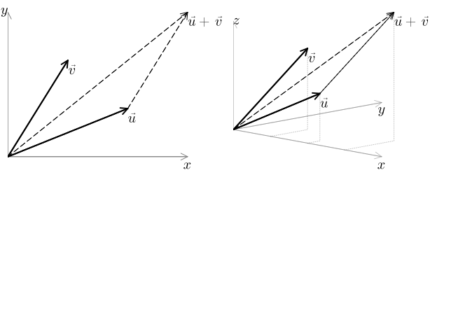

Figure 57.1: Illustration of vector addition in $2$ and $3$ dimensions

### 57.1.2 Scalar multiplication

Another operation for vectors is *scalar* multiplication. Geometrically this changes the magnitude, but not the direction of a vector, when the *scalar* is positive. Scalar multiplication is defined component wise, like addition so the $i$th component of $c \vec{v}$ is $c$ times the $i$th component of $\vec{v}$.

**NoteScalar multiplication**

$$c \cdot \langle a_1, a_2, \dots, a_n \rangle =
\langle c\cdot a_1, c \cdot a_2 , \dots, c \cdot a_n \rangle$$

When the scalar is negative, the direction is “reversed.”

To illustrate we define two $3$-dimensional vectors:

```julia
u, v = [1, 2, 3], [4, 3, 2]
```

```
([1, 2, 3], [4, 3, 2])
```

The sum is component-wise summation (`1+4, 2+3, 3+2`):

```julia
u + v
```

```
3-element Vector{Int64}:
 5
 5
 5
```

For addition, as the components must pair off, the two vectors being added must be the same dimension.

Scalar multiplication by `2`, say, multiplies each entry by `2`:

```julia
2 * u
```

```
3-element Vector{Int64}:
 2
 4
 6
```

### 57.1.3 The length and direction of a vector

If a vector $\vec{v} = \langle v_1, v_2, \dots, v_n\rangle$ then the *norm* (also Euclidean norm or length) of $\vec{v}$ is defined by:

$$\| \vec{v} \| = \sqrt{ v_1^2 + v_2^2 + \cdots + v_n^2}.$$

The definition of a norm leads to a few properties. First, if $c$ is a scalar, $\| c\vec{v} \| = |c| \| \vec{v} \|$—which says scalar multiplication by $c$ changes the length by $|c|$. (Sometimes, scalar multiplication is described as “scaling by….”) The other property is an analog of the triangle inequality, in which for any two vectors $\| \vec{v} + \vec{w} \| \leq \| \vec{v} \| + \| \vec{w} \|$. The right hand side is equal only when the two vectors are parallel.

A vector with length $1$ is called a *unit* vector. Dividing a non-zero vector by its norm will yield a unit vector, a consequence of the first property above. Unit vectors are often written with a “hat:” $\hat{v}$.

The direction indicated by $\vec{v}$ can be visualized as an angle in $2$- or $3$-dimensions, but in higher dimensions, visualization is harder. For $2$-dimensions, we might associate with a vector, it’s unit vector. This in turn may be identified with a point on the unit circle, which from basic trigonometry can be associated with an angle. Something similar, can be done in $3$ dimensions, using two angles. However, the “direction” of a vector is best thought of in terms of its associated unit vector. With this, we have a decomposition of a non-zero vector $\vec{v}$ into a magnitude and a direction when we write $\vec{v} = \|\vec{v}\| \cdot (\vec{v} / \|\vec{v}\|)=\|\vec{v}\| \hat{v}$.

### 57.1.4 Visualization of vectors

Vectors may be visualized in $2$ or $3$ dimensions using `Plots`. In $2$ dimensions, the `quiver` function may be used. To graph a vector, it must have its tail placed at a point, so two values are needed.

To plot `u=[1,2]` from `p=[0,0]` we have the following usage:

```julia
quiver([0],[0], quiver=([1],[2]))
```

The cumbersome syntax, `quiver(x, y, quiver=(u, v))`, is typical here. We naturally describe vectors and points using `[a,b,c]` to combine them, but the plotting functions want to plot many such at a time and expect vectors containing just the `x` values, just the `y` values, etc. The above usage looks a bit odd, as these vectors of `x` and `y` values have only one entry.

Converting from the one representation to the other requires reshaping the data. We will use the `unzip` function from `CalculusWithJulia` which in turn just uses the `invert` function of the `SplitApplyCombine` package (“return a new nested container by reversing the order of the nested container”) for the bulk of its work.

This function takes a vector of vectors, and returns a tuple containing the `x` values, the `y` values, etc. So if `u=[1,2,3]` and `v=[4,5,6]`, then `unzip([u,v])` becomes `([1,4],[2,5],[3,6])`, etc. (The `zip` function in base does essentially the reverse operation, hence the name.) Notationally, `A = [u,v]` can have the third element of the first vector (`u`) accessed by `A[1][3]`, where as `unzip(A)[3][1]` will do the same. We use `unzip([u])` in the following, which for this `u` returns `([1],[2],[3])`. (Note the `[u]` to make a vector of a vector.)

With `unzip` defined, we can plot a $2$-dimensional vector `v` anchored at point `p` through `quiver(unzip([p])..., quiver=unzip([v]))`.

To illustrate, the following defines $3$ vectors (the third through addition), then graphs all three, though in different starting points to emphasize the geometric interpretation of vector addition.

```julia
u = [1, 2]
v = [4, 2]
w = u + v
p = [0,0]
quiver(unzip([p])..., quiver=unzip([u]))
quiver!(unzip([u])..., quiver=unzip([v]))
quiver!(unzip([p])..., quiver=unzip([w]))
```

For some plotting backends—though not `plotly`— there is an `arrow` argument that can be passed to the line-plotting command. If `p` and `u` are *tuples*, then the command `plot([p, p .+ u]; arrow=true, side=:head)` will draw the vector `u` anchored at `p`. (There can be many more points in the curve used to create curved arrows.)

Plotting a $3$-d vector is not supported in all toolkits with `quiver`. A line segment may be substituted and can be produced with `plot(unzip([p,p+v])...)`. To avoid all these details, the `CalculusWithJulia` provides the `arrow!` function to *add* a vector to an existing plot. The function requires a point, `p`, and the vector, `v`:

With this, the above simplifies to:

```julia
u = [1, 2]
v = [4, 2]
w = u + v
p = [0,0]
plot(legend=false)
arrow!(p, u)
arrow!(u, v)
arrow!(p, w)
```

The distinction between a point and a vector within `Julia` is only mental. We often use the same storage type (`Vector`). Mathematically, we can **identify** a point and a vector, by considering the vector with its tail placed at the origin. In this case, the tip of the arrow is located at the point. But this is only an identification, though a useful one. It allows us to “add” a point and a vector (e.g., writing $P + \vec{v}$) by imagining the point as a vector anchored at the origin. (If `P` is represented with a tuple, we can still add to a vector through broadcasting: `P .+ v`.)

To see that a unit vector has the same “direction” as the vector, we might draw them with different widths:

```julia
v = [2, 3]
u = v / norm(v)
p = [0, 0]
plot(legend=false)
arrow!(p, v)
arrow!(p, u, linewidth=5)
```

The `norm` function is in the standard library, `LinearAlgebra`, which must be loaded first through the command `using LinearAlgebra`. (Though here it is redundant, as that package is loaded and reexported when the `CalculusWithJulia` package is loaded.)

#### Aside: review of `Julia`’s use of dots to work with containers

`Julia` makes use of the dot, “`.`”, in a few ways to simplify usage when containers, such as vectors, are involved:

##### Splatting

The use of three dots, “`...`”, to “splat” the values from a container like a vector (or tuple) into *arguments* of a function can be very convenient. It was used above in the definition for the `arrow!` function: essentially `quiver!(unzip([p])..., quiver=unzip([v]))`. The `quiver` function expects $2$ (or $3$) arguments describing the `xs` and `ys` (and sometimes `zs`). The `unzip` function returns these in a container, so splatting is used to turn the values in the container into distinct arguments of the function. Whereas the `quiver` argument expects a tuple of vectors, so no splatting is used for that part of the definition. Another use of splatting we will see is with functions of vectors. These can be defined in terms of the vector’s components or the vector as a whole, as below:

```julia
f(x, y, z) = x^2 + y^2 + z^2
f(v) = v[1]^2 + v[2]^2 + v[3]^2
```

```
f (generic function with 2 methods)
```

The first uses the components and is arguably, much easier to read. The second uses indexing in the function body to access the components. It has an advantage, as it can more easily handle different length vectors (e.g. using `sum(v.^2)`). Both uses have their merits, though the latter is more idiomatic throughout `Julia`.

If a function is easier to write in terms of its components, but an interface expects a vector of components as it argument, then splatting can be useful, to go from one style to another, similar to this:

```julia
g(x, y, z) = x^2 + y^2 + z^2
g(v) = g(v...)
```

```
g (generic function with 2 methods)
```

The splatting will mean `g(v)` eventually calls `g(x, y, z)` through `Julia`’s multiple dispatch machinery when `v = [x, y, z]`.

(The three dots can also appear in the definition of the arguments to a function, but there the usage is not splatting but rather a specification of a variable number of arguments.)

##### Broadcasting

For a univariate function, `f`, and vector, `xs`, the call `f.(xs)` *broadcasts* `f` over each value of `xs` and returns a container holding all the values. This is a compact alternative to a comprehension when a function is defined. When `f` depends on more than one value, broadcasting can still be used: `f.(xs, ys)` will broadcast `f` over values formed from *both* `xs` and `ys`. Broadcasting has the extra feature (over `map`) of attempting to match up the shapes of `xs` and `ys` when they are not identical. (See the help page for `broadcast` for more details.)

For example, if `xs` is a vector and `ys` a scalar, then the value in `ys` is repeated many times to match up with the values of `xs`. Or if `xs` and `ys` have different dimensions, the values of one will be repeated. Consider this:

```julia
f(x,y) = x + y
```

```
f (generic function with 3 methods)
```

```julia
xs = ys = [0, 1]
f.(xs, ys)
```

```
2-element Vector{Int64}:
 0
 2
```

This matches `xs` and `ys` to pass `(0,0)` and then `(1,1)` to `f`, returning `0` and `2`. Now consider

```julia
xs = [0, 1]; ys = [0 1]  # xs is a column vector, ys a row vector
f.(xs, ys)
```

```
2×2 Matrix{Int64}:
 0  1
 1  2
```

The two dimensions are different so for each value of `xs` the vector of `ys` is broadcast. This returns a matrix now. This will be important for some plotting usages where a grid (matrix) of values is needed.

At times using the “apply” notation: `x |> f`, in place of using `f(x)` is useful, as it can move the wrapping function to the right of the expression. To broadcast, `.|>` is available.

### 57.1.5 The dot product

There is no concept of multiplying two vectors, or for that matter dividing two vectors. However, there are two operations between vectors that are somewhat similar to multiplication, these being the dot product and the cross product. Each has an algebraic definition, but their geometric properties are what motivate their usage. We begin by discussing the dot product.

The dot product between two vectors can be viewed algebraically in terms of the following product. If $\vec{v} = \langle v_1, v_2, \dots, v_n\rangle$ and $\vec{w} = \langle w_1, w_2, \dots, w_n\rangle$, then the *dot product* of $\vec{v}$ and $\vec{w}$ is defined by:

$$\vec{v} \cdot \vec{w} = v_1 w_1 + v_2 w_2 + \cdots + v_n w_n.$$

From this, we can see the relationship between the norm, or Euclidean length of a vector: $\vec{v} \cdot \vec{v} = \| \vec{v} \|^2$. We can also see that the dot product is commutative, that is $\vec{v} \cdot \vec{w} = \vec{w} \cdot \vec{v}$.

The dot product has an important geometrical interpolation. Two (non-parallel) vectors will lie in the same “plane”, even in higher dimensions. Within this plane, there will be an angle between them within $[0, \pi]$. Call this angle $\theta$. (This means the angle between the two vectors is the same regardless of their order of consideration.) Then

$$\vec{v} \cdot \vec{w} = \|\vec{v}\| \|\vec{w}\| \cos(\theta).$$

If we denoted $\hat{v} = \vec{v} / \| \vec{v} \|$, the unit vector in the direction of $\vec{v}$, then by dividing, we see that

$$\cos(\theta) = \hat{v} \cdot \hat{w}.$$

That is, the angle does not depend on the magnitude of the vectors involved.

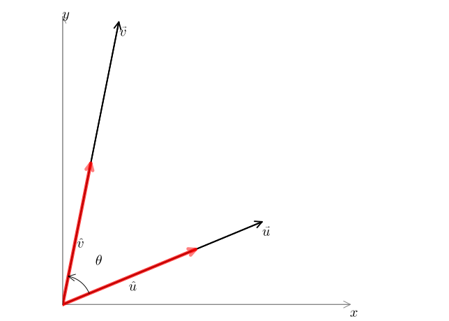

Figure 57.2: The angle between two vectors is the same as that between their unit vectors. It can be defined to be between $0$ and $\pi$. Its cosine is realized by the dot product of the unit vectors, $\hat{u} \cdot \hat{v}$.

The dot product is computed in `Julia` by the `dot` function, which is in the `LinearAlgebra` package of the standard library. This must be loaded (as above) before its use either directly or through the `CalculusWithJulia` package:

```julia
u = [1, 2]
v = [2, 1]
dot(u, v)
```

```
4
```

**NoteNote**

In `Julia`, the unicode operator entered by `\cdot[tab]` can also be used to mirror the math notation:

```julia
u ⋅ v   # u \cdot[tab] v
```

```
4
```

Continuing, to find the angle between $\vec{u}$ and $\vec{v}$, we might do this:

```julia
cos_theta = dot(u/norm(u), v/norm(v))
acos(cos_theta)
```

```
0.6435011087932845
```

The cosine of $\pi/2$ is $0$, so two vectors which are at right angles to each other will have a dot product of $0$:

```julia
u = [1, 2]
v = [2, -1]
u ⋅ v
```

```
0
```

In two dimensions, we learn that a perpendicular line to a line with slope $m$ will have slope $-1/m$. From a $2$-dimensional vector, say $\vec{u} = \langle u_1, u_2 \rangle$, the slope is $u_2/u_1$ so a perpendicular vector to $\vec{u}$ will be $\langle u_2, -u_1 \rangle$, as above. For higher dimensions, where the angle is harder to visualize, the dot product defines perpendicularness, or *orthogonality*.

For example, these two vectors are orthogonal, as their dot product is $0$, even though we can’t readily visualize them:

```julia
u = [1, 2, 3, 4, 5]
v = [-30, 4, 3, 2, 1]
u ⋅ v
```

```
0
```

#### Projection

A key fact about *non* parallel vectors, $\vec{u}$ and $\vec{v}$, is that $\vec{v}$ can be expressed as a scalar multiple of $\vec{u}$ plus a second vector which is orthogonal to $\vec{u}$.

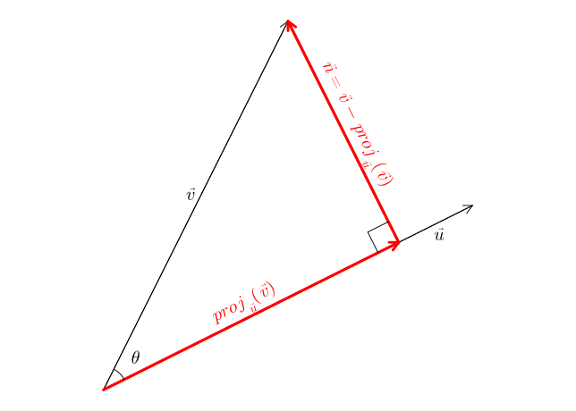

Figure 57.3: The vector $\vec{v}$ *projected* onto $\vec{u}$ decomposes $\vec{v}$ into a sum of vectors—one is parallel to $\vec{u}$ the other orthogonal.

In Figure 57.3 we see graphically the decomposition. The length of the vector parallel to $\vec{u}$ can be seen from right-triangle geometry to be $\lVert \vec{v} \rVert \cos(\theta)$, so the vector parallel to $\vec{u}$ would be this length times the unit vector in the direction of $\vec{u}$.

**NoteProjection of one vector onto another**

$$\begin{align*}
\text{proj}_{\vec{u}}(\vec{v})
&= \lVert \vec{v} \rVert \cos(\theta) \hat{u} \\
&= \frac{\vec{v} \cdot \vec{u}}{\lVert\vec{u}\rVert} \frac{\vec{u}}{\lVert\vec{u}\rVert} \\
&= (\vec{v} \cdot \hat{u}) \hat{u}.
\end{align*}$$

With this projection function, the orthogonal piece can be recovered by subtraction: $\vec{v} - (\vec{v} \cdot \hat{u}) \hat{u}$.

This is readily seen to be orthogonal to $\vec{u}$ just by taking the dot product.

##### Example

A pendulum, a bob on a string, swings back and forth due to the force of gravity. When the bob is displaced from rest by an angle $\theta$, then the tension force of the string on the bob is directed along the string and has magnitude given by the *projection* of the force due to gravity.

A [force diagram](https://en.wikipedia.org/wiki/Free_body_diagram) is a useful visualization device of physics to illustrate the applied forces involved in a scenario. In this case the bob has two forces acting on it: a force due to tension in the string of unknown magnitude, but in the direction of the string; and a force due to gravity. The latter is in the downward direction and has magnitude $mg$, $g=9.8m/sec^2$ being the gravitational constant.

```julia
theta = pi/12
mass, gravity = 1/9.8, 9.8

R = [-sin(theta), cos(theta)]
p = -R
Fg = [0, -mass * gravity]
plot(legend=false)
arrow!(p, R)
arrow!(p, Fg)
scatter!(p[1:1], p[2:2], markersize=5)
```

The magnitude of the tension force is exactly that of the force of gravity projected onto $\vec{l}$, as the bob is not accelerating in that direction. The component of the gravity force in the perpendicular direction is the part of the gravitational force that causes acceleration in the pendulum. Here we find the projection onto $\vec{l}$ and visualize the two components of the gravitational force.

```julia
plot(legend=false, aspect_ratio=:equal)
arrow!(p, R)
arrow!(p, Fg)
scatter!(p[1:1], p[2:2], markersize=5)

proj = (Fg ⋅ R) / (R ⋅ R) * R   # force of gravity in direction of tension
porth = Fg - proj              # force of gravity perpendicular to tension

arrow!(p, proj)
arrow!(p, porth, linewidth=3)
```

##### Example

Starting with three vectors, we can create three orthogonal vectors using projection and subtraction. The creation of `porth` above is the pattern we will exploit.

Let’s begin with three vectors in $R^3$:

```julia
u = [1, 2, 3]
v = [1, 1, 2]
w = [1, 2, 4]
```

```
3-element Vector{Int64}:
 1
 2
 4
```

We can find a vector from `v` orthogonal to `u` using:

```julia
unit_vec(u) = u / norm(u)
projection(u, v) = (u ⋅ unit_vec(v)) * unit_vec(v)

vₚ = v - projection(v, u)
wₚ = w - projection(w, u) - projection(w, vₚ)
```

```
3-element Vector{Float64}:
 -0.33333333333333265
 -0.3333333333333336
  0.33333333333333354
```

We can verify the orthogonality through:

```julia
u ⋅ vₚ, u ⋅ wₚ, vₚ ⋅ wₚ
```

```
(-3.3306690738754696e-16, 8.881784197001252e-16, 3.661092593109147e-16)
```

This only works when the three vectors do not all lie in the same plane. In general, this is the beginning of the [Gram-Schmidt](https://en.wikipedia.org/wiki/Gram-Schmidt_process) process for creating *orthogonal* vectors from a collection of vectors.

#### Algebraic properties

The dot product is similar to multiplication, but different, as it is an operation defined between vectors of the same dimension. However, many algebraic properties carry over:

- commutative: $\vec{u} \cdot \vec{v} = \vec{v} \cdot \vec{u}$
- scalar multiplication: $(c\vec{u})\cdot\vec{v} = c(\vec{u}\cdot\vec{v})$.
- distributive $\vec{u} \cdot (\vec{v} + \vec{w}) = \vec{u} \cdot \vec{v} + \vec{u} \cdot \vec{w}$

The last two can be combined: $\vec{u}\cdot(s \vec{v} + t \vec{w}) = s(\vec{u}\cdot\vec{v}) + t (\vec{u}\cdot\vec{w})$.

But the associative property does not, as $(\vec{u} \cdot \vec{v}) \cdot \vec{w}$ does not make sense as two dot products: the result of the first is not a vector, but a scalar.

### 57.1.6 Cross product

In three dimensions, there is another operation between vectors that is similar to multiplication, though we will see with many differences.

Let $\vec{u}$ and $\vec{v}$ be two $3$-dimensional vectors, then the *cross* product, $\vec{u} \times \vec{v}$, is defined as a vector with length:

$$\| \vec{u} \times \vec{v} \| = \| \vec{u} \| \| \vec{v} \| \sin(\theta),$$

with $\theta$ being the angle in $[0, \pi]$ between $\vec{u}$ and $\vec{v}$. Consequently, $\sin(\theta) \geq 0$.

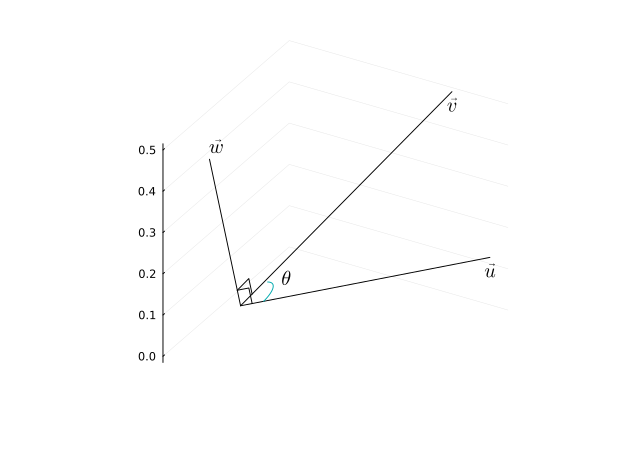

Figure 57.4: Cross product of $\vec{u}$ and $\vec{v}$ will be orthogonal to both with length given by the lengths of both vectors and the sine of the angle between them.

The direction of the cross product is such that it is *orthogonal* to *both* $\vec{u}$ and $\vec{v}$. There are two such directions, to identify which is correct, the [right-hand rule](https://en.wikipedia.org/wiki/Cross_product#Definition) is used. This rule points the right hand fingers in the direction of $\vec{u}$ and curls them towards $\vec{v}$ (so that the angle between the two vectors is in $[0, \pi]$). The thumb will point in the direction. Call this direction $\hat{n}$, a normal unit vector. Then the cross product can be defined by:

$$\vec{u} \times \vec{v} = \| \vec{u} \| \| \vec{v} \| \sin(\theta) \hat{n}.$$

**NoteThe right-hand rule**

The right-hand rule is also useful to understand how standard household screws will behave when twisted with a screwdriver. If the right hand fingers curl in the direction of the twisting screwdriver, then the screw will go in or out following the direction pointed to by the thumb.

The right-hand rule depends on the order of consideration of the vectors. If they are reversed, the opposite direction is determined. A consequence is that the cross product is **anti**-commutative, unlike multiplication:

$$\vec{u} \times \vec{v} = - \vec{v} \times \vec{u}.$$

Mathematically, the definition in terms of its components is a bit involved.

$$\vec{u} \times \vec{v} = \langle u_2 v_3 - u_3 v_2, u_3 v_1 - u_1 v_3, u_1 v_2 - u_2 v_1 \rangle.$$

From the $\sin(\theta)$ term in the definition, we see that $\vec{u}\times\vec{u}=0$. In fact, the cross product is $0$ only if the two vectors involved are parallel or there is a zero vector.

In `Julia`, the `cross` function from the `LinearAlgebra` package implements the cross product. For example:

```julia
a = [1, 2, 3]
b = [4, 2, 1]
cross(a, b)
```

```
3-element Vector{Int64}:
 -4
 11
 -6
```

There is also the *infix* unicode operator `\times[tab]` that can be used for similarity to traditional mathematical syntax.

```julia
a × b
```

```
3-element Vector{Int64}:
 -4
 11
 -6
```

We can see the cross product is anti-commutative by comparing the last answer with:

```julia
b × a
```

```
3-element Vector{Int64}:
   4
 -11
   6
```

Using vectors of size different than $n=3$ produces a dimension mismatch error:

```julia
[1, 2] × [3, 4]
```

```
DimensionMismatch: cross product is only defined for vectors of length 3
Stacktrace:
 [1] cross(a::Vector{Int64}, b::Vector{Int64})
   @ LinearAlgebra ~/.julia/juliaup/julia-1.12.0+0.aarch64.apple.darwin14/share/julia/stdlib/v1.12/LinearAlgebra/src/generic.jl:413
 [2] top-level scope
   @ ~/julia/CalculusWithJuliaNotes/quarto/differentiable_vector_calculus/vectors.qmd:799
```

(It can prove useful to pad $2$-dimensional vectors into $3$-dimensional vectors by adding a $0$ third component. We will see this in the discussion on curvature in the plane.)

Consider this extended picture involving two vectors $\vec{u}$ and $\vec{v}$ drawn in two dimensions:

```julia
u₁ = [1, 2]
v₁ = [2, 1]
p₁ = [0,0]

plot(aspect_ratio=:equal)
arrow!(p₁, u₁)
arrow!(p₁, v₁)
arrow!(u₁, v₁)
arrow!(v₁, u₁)

puv₁ = (u₁ ⋅ v₁) / (v₁ ⋅ v₁) * v₁
porth₁ = u₁ - puv₁
arrow!(puv₁, porth₁)
```

The enclosed shape is a parallelogram. To this we added the projection of $\vec{u}$ onto $\vec{v}$ (`puv`) and then the *orthogonal* part (`porth`).

The *area* of a parallelogram is the length of one side times the perpendicular height. The perpendicular height could be found from `norm(porth)`, so the area is:

```julia
norm(v₁) * norm(porth₁)
```

```
3.0
```

However, from trigonometry we have the height would also be the norm of $\vec{u}$ times $\sin(\theta)$, a value that is given through the length of the cross product of $\vec{u}$ and $\hat{v}$, the unit vector, were these vectors viewed as $3$ dimensional by adding a $0$ third component. In formulas, this is also the case:

$$\text{area of the parallelogram} = \| \vec{u} \times \hat{v} \| \| \vec{v} \| = \| \vec{u} \times \vec{v} \|.$$

We have, for our figure, after extending `u` and `v` to be three dimensional the area of the parallelogram:

```julia
u₂ = [1, 2, 0]
v₂ = [2, 1, 0]
norm(u₂ × v₂)
```

```
3.0
```

This analysis can be extended to the case of 3 vectors, which—when not co-planar—will form a *parallelepiped*.

```julia
u₃, v₃, w₃ = [1,2,3], [2,1,0], [1,1,2]
plot()
p₃ = [0,0,0]

plot(legend=false)
arrow!(p₃, u₃); arrow!(p₃, v₃); arrow!(p₃, w₃)
arrow!(u₃, v₃); arrow!(u₃, w₃)
arrow!(v₃, u₃); arrow!(v₃, w₃)
arrow!(w₃, u₃); arrow!(w₃, v₃)
arrow!(u₃ + v₃, w₃); arrow!(u₃ + w₃, v₃); arrow!(v₃ + w₃, u₃)
```

The volume of a parallelepiped is the area of a base parallelogram times the height of a perpendicular. If $\vec{u}$ and $\vec{v}$ form the base parallelogram, then the perpendicular will have height $\|\vec{w}\| \cos(\theta)$ where the angle is the one made by $\vec{w}$ with the normal, $\vec{n}$. Since $\vec{u} \times \vec{v} = \| \vec{u} \times \vec{v}\| \hat{n} = \hat{n}$ times the area of the base parallelogram, we have if we dot this answer with $\vec{w}$:

$$(\vec{u} \times \vec{v}) \cdot \vec{w} =
\|\vec{u} \times \vec{v}\| (\vec{n} \cdot \vec{w}) =
\|\vec{u} \times \vec{v}\| \| \vec{w}\| \cos(\theta),$$

**NoteOrientation**

The triple-scalar product, $\vec{u}\cdot(\vec{v}\times\vec{w})$, gives the volume of the parallelepiped up to sign. If the sign of this is positive, the $3$ vectors are said to have a *positive* orientation, if the triple-scalar product is negative, the vectors have a *negative* orientation.

#### Algebraic properties

The cross product has many properties, some different from regular multiplication:

- scalar multiplication: $(c\vec{u})\times\vec{v} = c(\vec{u}\times\vec{v})$
- distributive over addition: $\vec{u} \times (\vec{v} + \vec{w}) = \vec{u}\times\vec{v} + \vec{u}\times\vec{w}$.
- *anti*-commutative: $\vec{u} \times \vec{v} = - \vec{v} \times \vec{u}$
- *not* associative: that is there is no guarantee that $(\vec{u}\times\vec{v})\times\vec{w}$ will be equivalent to $\vec{u}\times(\vec{v}\times\vec{w})$.
- The triple cross product $(\vec{u}\times\vec{v}) \times \vec{w}$ must be orthogonal to $\vec{u}\times\vec{v}$ so lies in a plane with this as a normal vector. But, $\vec{u}$ and $\vec{v}$ will generate this plane, so it should be possible to express this triple product in terms of a sum involving $\vec{u}$ and $\vec{v}$ and indeed:

$$(\vec{u}\times\vec{v})\times\vec{w} = (\vec{u}\cdot\vec{w})\vec{v} - (\vec{v}\cdot\vec{w})\vec{u}.$$

The following shows the algebraic properties stated above hold for symbolic vectors. First the linearity of the dot product:

```julia
@syms s₄ t₄ u₄[1:3]::real v₄[1:3]::real w₄[1:3]::real

u₄ ⋅ (s₄ * v₄ + t₄ * w₄) - (s₄ * (u₄ ⋅ v₄) + t₄ * (u₄ ⋅ w₄)) |> simplify
```

$0$

This shows the dot product is commutative:

```julia
(u₄ ⋅ v₄) - (v₄ ⋅ u₄) |> simplify
```

$0$

This shows the linearity of the cross product over scalar multiplication and vector addition:

```julia
u₄ × (s₄* v₄ + t₄ * w₄) - (s₄ * (u₄ × v₄) + t₄ * (u₄ × w₄)) .|> simplify
```

$\left[\begin{smallmatrix}0\\0\\0\end{smallmatrix}\right]$

(We use `.|>` to broadcast `simplify` over each component.)

The cross product is anti-commutative:

```julia
u₄ × v₄ + v₄ × u₄ .|> simplify
```

$\left[\begin{smallmatrix}0\\0\\0\end{smallmatrix}\right]$

but not associative:

```julia
u₄ × (v₄ × w₄) - (u₄ × v₄) × w₄ .|> simplify
```

$\left[\begin{smallmatrix}u₄₁ v₄₂ w₄₂ + u₄₁ v₄₃ w₄₃ - u₄₂ v₄₂ w₄₁ - u₄₃ v₄₃ w₄₁\\- u₄₁ v₄₁ w₄₂ + u₄₂ v₄₁ w₄₁ + u₄₂ v₄₃ w₄₃ - u₄₃ v₄₃ w₄₂\\- u₄₁ v₄₁ w₄₃ - u₄₂ v₄₂ w₄₃ + u₄₃ v₄₁ w₄₁ + u₄₃ v₄₂ w₄₂\end{smallmatrix}\right]$

Finally we verify the decomposition of the triple cross product:

```julia
(u₄ × v₄) × w₄ - ( (u₄ ⋅ w₄) * v₄ - (v₄ ⋅ w₄) * u₄) .|> simplify
```

$\left[\begin{smallmatrix}0\\0\\0\end{smallmatrix}\right]$

This table shows common usages of the symbols for various multiplication types: `*`, $\cdot$, and $\times$:

| Symbol | inputs | output | type |
| --- | --- | --- | --- |
| `*` | scalar, scalar | scalar | regular multiplication |
| `*` | scalar, vector | vector | scalar multiplication |
| `*` | vector, vector | *undefined* |  |
| $\cdot$ | scalar, scalar | scalar | regular multiplication |
| $\cdot$ | scalar, vector | vector | scalar multiplication |
| $\cdot$ | vector, vector | scalar | dot product |
| $\times$ | scalar, scalar | scalar | regular multiplication |
| $\times$ | scalar, vector | undefined |  |
| $\times$ | vector, vector | vector | cross product ($3$D) |

### 57.1.7 Parameterized lines and planes

A line in two dimensions satisfies the equation $ax + by = c$. Suppose $a$ and $b$ are non-zero. This can be represented in vector form, as the collection of all points associated to the vectors: $p + t \vec{v}$ where $p$ is a point on the line, say $(0,c/b)$, and v is the vector $\langle b, -a \rangle$. We can verify, this for values of `t` as follows:

```julia
@syms a b c x y t

eq = c - (a*x + b*y)

p = [0, c/b]
v = [-b, a]
li = p + t * v

eq(x=>li[1], y=>li[2]) |> simplify
```

$0$

Let $\vec{n} = \langle a , b \rangle$, taken from the coefficients in the equation. We can see directly that $\vec{n}$ is orthogonal to $\vec{v}$. The line may then be seen as the collection of all vectors that are orthogonal to $\vec{n}$ that have their tail at the point $p$.

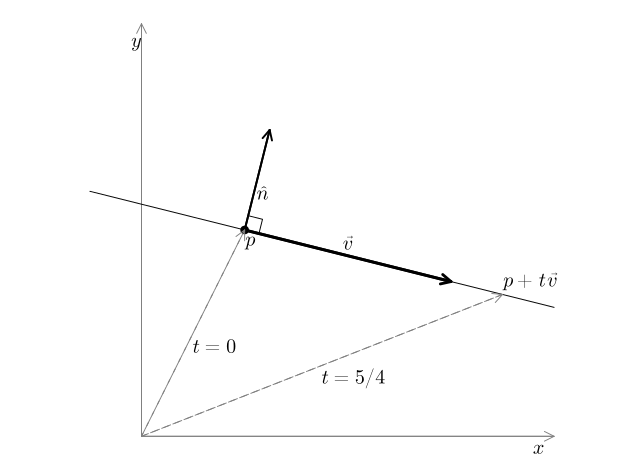

Figure 57.5: Parameterized line through the point $p$ along vector $\vec{v}$. The line can be described by $l(t) = p + t\cdot \vec{v}$ or as all vector orthogonal to $\hat{n}$ anchored at $p$.

In three dimensions, the equation of a plane is $ax + by + cz = d$. Suppose, $a$, $b$, and $c$ are non-zero, for simplicity. Setting $\vec{n} = \langle a,b,c\rangle$ by comparison, it can be seen that plane is identified with the set of all vectors orthogonal to $\vec{n}$ that are anchored at $p$.

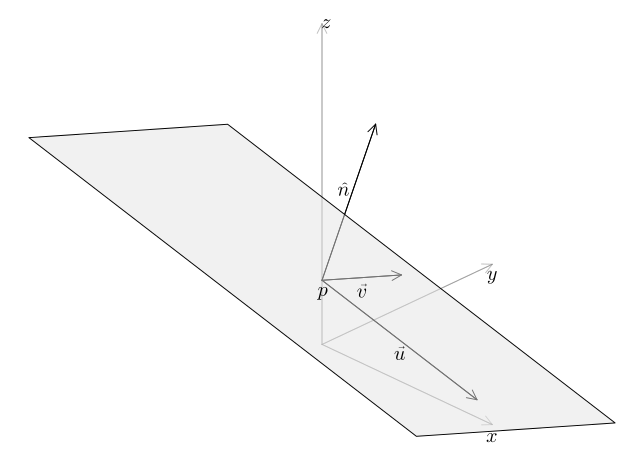

Figure 57.6: A plane can be described as all vectors orthogonal to $\hat{n}$ which are anchored at a point $p$ or through a parameterization $p + s\vec{u} + t\vec{v}$.

First, let $p = (0, 0, d/c)$ be a point on the plane. We find two vectors $u = \langle -b, a, 0 \rangle$ and $v = \langle 0, c, -b \rangle$. Then any point on the plane may be identified with the vector $p + s\vec{u} + t\vec{v}$. We can verify this algebraically through:

```julia
@syms a b c d x y z s t

eq = d - (a*x + b*y + c * z)

p = [0, 0, d/c]
u, v = [-b, a, 0], [0, c, -b]
pl = p + t * u + s * v

subs(eq, x=>pl[1], y=>pl[2], z=>pl[3]) |> simplify
```

$0$

The above viewpoint can be reversed:

> a plane is determined by two (non-parallel) vectors and a point.

The parameterized version of the plane would be $p + s \vec{u} + t \vec{v}$, as used above.

The equation of the plane can be given from $\vec{u}$ and $\vec{v}$. Let $\vec{n} = \vec{u} \times \vec{v}$. Then $\vec{n} \cdot \vec{u} = \vec{n} \cdot \vec{v} = 0$, from the properties of the cross product. As such, $\vec{n} \cdot (s \vec{u} + t \vec{v}) = 0$. That is, the cross product is orthogonal to any *linear* combination of the two vectors. This figure shows one such linear combination:

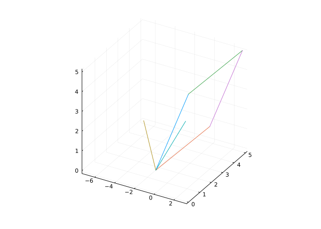

```julia
u = [1,2,3]
v = [2,3,1]
n = u × v
p = [0,0,1]

plot(legend=false)

arrow!(p, u)
arrow!(p, v)
arrow!(p + u, v)
arrow!(p + v, u)
arrow!(p, n)

s, t = 1/2, 1/4
arrow!(p, s*u + t*v)
```

So if $\vec{n} \cdot p = d$ (identifying the point $p$ with a vector so the dot product is defined), we will have for any vector $\vec{v} = \langle x, y, z \rangle = s \vec{u} + t \vec{v}$ that

$$\vec{n} \cdot (p + s\vec{u} + t \vec{v}) = \vec{n} \cdot p + \vec{n} \cdot (s \vec{u} + t \vec{v}) = d + 0 = d,$$

But if $\vec{n} = \langle a, b, c \rangle$, then this says $d = ax + by + cz$, so from $\vec{n}$ and $p$ the equation of the plane is given.

In summary:

| Object | Equation | vector equation |
| --- | --- | --- |
| Line | $ax + by = c$ | line: $p + t\vec{u}$ |
| Plane | $ax + by + cz = d$ | plane: $p + s\vec{u} + t\vec{v}$ |

##### Example

You are given that the vectors $\vec{u} =\langle 6, 3, 1 \rangle$ and $\vec{v} = \langle 3, 2, 1 \rangle$ describe a plane through the point $p=[1,1,2]$. Find the equation of the plane.

The key is to find the normal vector to the plane, $\vec{n} = \vec{u} \times \vec{v}$:

```julia
u, v, p = [6,3,1], [3,2,1], [1,1,2]
n = u × v
a, b, c = n
d = n ⋅ p
"equation of plane: $a x + $b y + $c z = $d"
```

```
"equation of plane: 1 x + -3 y + 3 z = 4"
```

##### Example: orthogonal

A line is described by a point $P=(a,b)$ and a vector $\vec{v} = \langle v_1, v_2 \rangle$ through $r(t) = P + t \vec{v}$.

A *normal* to the line is given by $\vec{n} = \langle -v_2, v_1 \rangle$. By construction, the value of $\vec{v} \cdot \vec{n}$ is $0$.

The line can also be described in terms of orthogonality by the equation

$$\vec{n} \cdot (\vec{x} - P) = 0,$$

where we treat $P$ as a vector for purposes of subtraction. That is, the line is comprised of all vectors anchored at $P$ orthogonal to $\vec{n}$.

Clearly, as $r(t) - P = \vec{v}$ we have $\vec{n} \cdot r(t) = 0$. Further, if $\vec{x}$ satisfies $\vec{n} \cdot (\vec{x} - P) = 0$ then again by flipping coordinates and taking a minus sign, we must have $\vec{x} - P$ is a multiple of $\langle v_1, v_2 \rangle = \vec{v}$.

Furthermore, suppose $P$ is a point in $R^3$ with two vectors $\vec{v}$ and $\vec{w}$ which are not parallel. Then the plane $P + s\vec{v} + t\vec{w}$ formed has a normal given by $\vec{n} = \vec{v} \times \vec{w}$. But $\vec{n} \cdot ((P + s\vec{v} + t\vec{w}) - P) = s\vec{n} \cdot \vec{v} + t \vec{n} \cdot \vec{w} = 0$ so again, we have the plane described as well by”

$$\vec{n} \cdot (\vec{x} - P) = 0.$$

If $\vec{n} = \langle a,b,d \rangle$ then from $\vec{n}\cdot x = \vec{n} \cdot P$ this becomes $ax + by + cz = d = \vec{n}\cdot P$, as we used in the last example.

##### Example: distance of a point

Consider a line in $R^2$ and a point, $Q$, not on the line. How far is the nearest point on the line to $Q$?

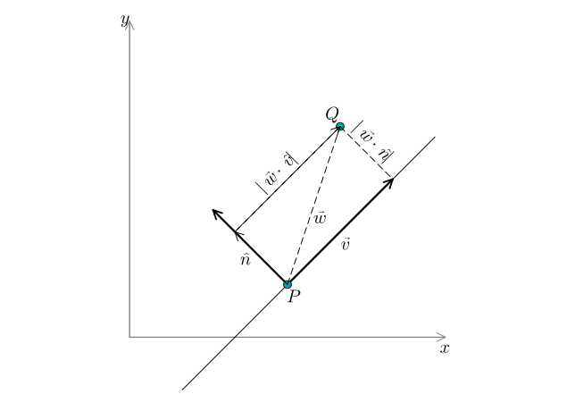

Figure 57.7: How far is point $Q$ to the line going through $P$ in direction $\vec{v}$?

Suppose the line goes through the point $P$ and is in direction $\vec{v}$. Let $\hat{n}$ be a unit normal vector to $\vec{v}$ and $\hat{v}$ be the unit vector in direction $\vec{v}$.

Then projection of $\vec{w}$ on $\vec{v}$ decomposes $\vec{w}$:

$$\vec{w} = (\vec{w}\cdot\hat{v}) \hat{v} + a \hat{n}$$

The length of $\text{proj}_{\vec{w}}(\vec{v})$ has been seen to be $\|\vec{w}\cdot\hat{v}\|$. The length of $a$ by a *similar* reason is $\|\vec{w} \cdot \hat{n}\|$. This is the length sought, so the distance from a point to a line is given by

$$\| \hat{n} \cdot \vec{PQ} \|.$$

**NoteDistance of point to a line and a plane**

Let $\hat{n}$ be normal to a line (in $R^2$) or plane (in $R^3$) which goes through a point $P$. Then the distance from a point $Q$ to the line or plane is given by
$$\text{dist}(Q) = \| \hat{n} \cdot \vec{PQ} \|.$$

##### Example: intersection

In $R^3$ consider a plane through a point $P=(1,2,3)$ with normal vector $\vec{n} = \langle 1, 1/2, 1/4\rangle$. Suppose a line goes through points $A=(2,3,1)$ and $B=(3,1,2)$. Where does this line intersect the plane?

We have the line is parameterized by $\vec{r}(t) = B + t \vec{AB}$ and the plane is described by $\vec{n} \cdot (\vec{x} - P) = 0$. The intersection point must be a $t$ that satisfies $\vec{n} \cdot (\vec{r}(t) - P) = 0$

We have:

```julia
P, A, B = [1,2,3], [2,3,1], [3,1,2]
n = [1, 1//2, 1//4]
@syms t
𝑟(t) = B + t * (B - A)
t₀ = only(solve(n ⋅ (𝑟(t) -P) ~ 0, t))
𝑟(t₀)
```

$\left[\begin{smallmatrix}-2\\11\\-3\end{smallmatrix}\right]$

##### Example: intersection

In $R^3$ two non-parallel planes will intersect in a line. How to describe that line?

Let the planes be described by points $P_1$ and $P_2$ with normal vectors $\vec{n_1}$ and $\vec{n_2}$. The line will lie in each of the two planes, so any point on the line will satisfy $\vec{n_i} \cdot (\vec{x} - P)= 0$ for $i=1,2$. The vector $\vec{v} = \vec{n_1} \times \vec{n_2}$ is perpendicular to both $\vec{n_1}$ and $\vec{n_2}$, so the line is in the direction of $\vec{v}$. To describe the line we need a point $Q$ on the line, then the description is $Q + t \vec{v}$.

Fix the $z$ coordinate of $Q$ to be $0$. Then we can solve for $Q$ in general through two linear equations in $x$ and $y$:

```julia
@syms n₁[1:3]::real, n₂[1:3]::real, p₁[1:3]::real, p₂[1:3]::real, x::real, y::real
q = [x, y, 0]
solve((n₁ ⋅ (q - p₁) ~ 0, n₂ ⋅ (q - p₂) ~ 0), (x, y))
```

$$\begin{equation*}\begin{cases}x & \text{=>} &\frac{n₁₁ n₂₂ p₁₁ - n₁₂ n₂₁ p₂₁ + n₁₂ n₂₂ p₁₂ - n₁₂ n₂₂ p₂₂ - n₁₂ n₂₃ p₂₃ + n₁₃ n₂₂ p₁₃}{n₁₁ n₂₂ - n₁₂ n₂₁}\\y & \text{=>} &\frac{- n₁₁ n₂₁ p₁₁ + n₁₁ n₂₁ p₂₁ + n₁₁ n₂₂ p₂₂ + n₁₁ n₂₃ p₂₃ - n₁₂ n₂₁ p₁₂ - n₁₃ n₂₁ p₁₃}{n₁₁ n₂₂ - n₁₂ n₂₁}\\\end{cases}\end{equation*}$$

## 57.2 Matrices

Algebraically, the dot product of two vectors—pair off by components, multiply these, then add—is a common operation. Take for example, the general equation of a line, or a plane:

$$ax + by = c, \quad ax + by + cz = d.$$

The left hand sides are in the form of a dot product, in this case $\langle a,b \rangle \cdot \langle x, y\rangle$ and $\langle a,b,c \rangle \cdot \langle x, y, z\rangle$ respectively. When there is a system of equations, something like:

$$M =
\begin{bmatrix}
3 & 4 & -5\\
5 &-5 & 7\\
-3& 6 & 9
\end{bmatrix},\quad
\vec{x} = \langle x, y , z\rangle,\quad
\vec{b} = \langle 10, 11, 12\rangle,$$

and the expression $M\vec{x} = \vec{b}$. The matrix $M$ is a rectangular collection of numbers or expressions arranged in rows and columns with certain algebraic definitions. There are $m$ rows and $n$ columns in an $m\times n$ matrix. In this example $m=n=3$, and in such a case the matrix is called square. A vector, like $\vec{x}$ is usually identified with the $n \times 1$ matrix (a column vector). Were that done, the system of equations would be written $Mx=b$.

If we refer to a matrix $M$ by its components, a convention is to use $(M)_{ij}$ or $m_{ij}$ to denote the entry in the $i$th *row* and $j$th *column*. Following `Julia`’s syntax, we would use $m_{i:}$ to refer to *all* entries in the $i$th row, and $m_{:j}$ to denote *all* entries in the $j$ column.

In addition to square matrices, there are some other common types of matrices worth naming: square matrices with $0$ entries below the diagonal are called upper triangular; square matrices with $0$ entries above the diagonal are called lower triangular matrices; square matrices which are $0$ except possibly along the diagonal are diagonal matrices; and a diagonal matrix whose diagonal entries are all $1$ is called an *identity matrix*.

Matrices, like vectors, have scalar multiplication defined for them. then scalar multiplication of a matrix $M$ by $c$ just multiplies each entry by $c$, so the new matrix would have components defined by $cm_{ij}$.

Matrices of the same size, like vectors, have addition defined for them. As with scalar multiplication, addition is defined component wise. So $A+B$ is the matrix with $ij$ entry $A_{ij} + B_{ij}$.

### 57.2.1 Matrix multiplication

Matrix multiplication may be viewed as a collection of dot product operations. First, matrix multiplication is only defined between $A$ and $B$, as $AB$, if the size of $A$ is $m\times n$ and the size of $B$ is $n \times k$. That is the number of columns of $A$ must match the number of rows of $B$ for the left multiplication of $AB$ to be defined. If this is so, then we have the $ij$ entry of $AB$ is:

$$(AB)_{ij} = A_{i:} \cdot B_{:j}.$$

That is, if we view the $i$th row of $A$ and the $j$th column of B as *vectors*, then the $ij$ entry is the dot product.

This is why $M$ in the example above, has the coefficients for each equation in a row and not a column, and why $\vec{x}$ is thought of as a $n\times 1$ matrix (a column vector) and not as a row vector.

Matrix multiplication between $A$ and $B$ is not, in general, commutative. Not only may the sizes not permit $BA$ to be found when $AB$ may be, there is just no guarantee when the sizes match that the components will be the same.

Matrices have other operations defined on them. We mention three here:

- The *transpose* of a matrix flips the difference between row and column, so the $ij$ entry of the transpose is the $ji$ entry of the matrix. This means the transpose will have size $n \times m$ when $M$ has size $m \times n$. Mathematically, the transpose is denoted $M^t$.
- The *determinant* of a *square* matrix is a number that can be used to characterize the matrix. The determinant may be computed different ways, but its [definition](https://en.wikipedia.org/wiki/Leibniz_formula_for_determinants) by the Leibniz formula is common. Two special cases are all we need. The $2\times 2$ case and the $3 \times 3$ case:

$$\begin{vmatrix}
a&b\\
c&d
\end{vmatrix}
=
ad - bc, \quad
\begin{vmatrix}
a&b&c\\
d&e&f\\
g&h&i
\end{vmatrix}
=
a
\begin{vmatrix}
e&f\\
h&i
\end{vmatrix}
- b
\begin{vmatrix}
d&f\\
g&i
\end{vmatrix}
+c
\begin{vmatrix}
d&e\\
g&h
\end{vmatrix}$$

The $3\times 3$ case shows how determinants may be [computed recursively](https://en.wikipedia.org/wiki/Determinant#Definition), using “cofactor” expansion.

- The *inverse* of a square matrix. If $M$ is a square matrix and its determinant is non-zero, then there is an *inverse* matrix, denoted $M^{-1}$, with the properties that $MM^{-1} = M^{-1}M = I$, where $I$ is the diagonal matrix of all $1$s called the identify matrix.

### 57.2.2 Matrices in Julia

As mentioned previously, a matrix in `Julia` is defined component by component with `[]`. We separate row entries with spaces and columns with semicolons:

```julia
M = [3 4 -5; 5 -5 7; -3 6 9]
```

```
3×3 Matrix{Int64}:
  3   4  -5
  5  -5   7
 -3   6   9
```

Space is the separator, which means computing a component during definition (i.e., writing `2 + 3` in place of `5`) can be problematic, as no space can be used in the computation, lest it be parsed as a separator.

Vectors are defined similarly. As they are identified with *column* vectors, we use a semicolon (or a comma with simple numbers) to separate:

```julia
a = [10, 11, 12]   # not a = [10 11 12], which would be a row vector.
```

```
3-element Vector{Int64}:
 10
 11
 12
```

In `Julia`, entries in a matrix (or a vector) are stored in a container with a type wide enough accommodate each entry. In this example, the type is SymPy’s `Sym` type:

```julia
@syms xs[1:3]
```

```
(Sym{PyCall.PyObject}[xs₁, xs₂, xs₃],)
```

Matrices may also be defined from blocks. This example shows how to make two column vectors into a matrix:

```julia
u = [10, 11, 12]
v = [13, 14, 15]
[u v]   # horizontally combine
```

```
3×2 Matrix{Int64}:
 10  13
 11  14
 12  15
```

Vertically combining the two will stack them:

```julia
[u; v]
```

```
6-element Vector{Int64}:
 10
 11
 12
 13
 14
 15
```

Scalar multiplication will just work as expected:

```julia
2 * M
```

```
3×3 Matrix{Int64}:
  6    8  -10
 10  -10   14
 -6   12   18
```

Matrix addition is also straightforward:

```julia
M + M
```

```
3×3 Matrix{Int64}:
  6    8  -10
 10  -10   14
 -6   12   18
```

Matrix addition expects matrices of the same size. An error will otherwise be thrown. However, if addition is *broadcasted* then the sizes need only be commensurate. For example, this will add `1` to each entry of `M`:

```julia
M .+ 1
```

```
3×3 Matrix{Int64}:
  4   5  -4
  6  -4   8
 -2   7  10
```

Matrix multiplication is defined by `*`:

```julia
M * M
```

```
3×3 Matrix{Int64}:
  44  -38  -32
 -31   87    3
  -6   12  138
```

We can then see how the system of equations is represented with matrices:

```julia
M * xs - a
```

$\left[\begin{smallmatrix}3 xs₁ + 4 xs₂ - 5 xs₃ - 10\\5 xs₁ - 5 xs₂ + 7 xs₃ - 11\\- 3 xs₁ + 6 xs₂ + 9 xs₃ - 12\end{smallmatrix}\right]$

Here we use `SymPy` to verify the above:

```julia
A = [symbols("A$i$j", real=true) for i in 1:3, j in 1:2]
B = [symbols("B$i$j", real=true) for i in 1:2, j in 1:2]
```

$\left[\begin{smallmatrix}B_{11} & B_{12}\\B_{21} & B_{22}\end{smallmatrix}\right]$

The matrix product has the expected size: the number of rows of `A` ($3$) by the number of columns of `B` ($2$):

```julia
A * B
```

$\left[\begin{smallmatrix}A_{11} B_{11} + A_{12} B_{21} & A_{11} B_{12} + A_{12} B_{22}\\A_{21} B_{11} + A_{22} B_{21} & A_{21} B_{12} + A_{22} B_{22}\\A_{31} B_{11} + A_{32} B_{21} & A_{31} B_{12} + A_{32} B_{22}\end{smallmatrix}\right]$

This confirms how each entry (`(A*B)[i,j]`) is from a dot product (`A[i,:] ⋅ B[:,j]`):

```julia
[ (A * B)[i,j] == A[i,:] ⋅ B[:,j] for i in 1:3, j in 1:2]
```

```
3×2 Matrix{Bool}:
 1  1
 1  1
 1  1
```

When the multiplication is broadcasted though, with `.*`, the operation will be component wise:

```julia
M .* M   # component wise (Hadamard product)
```

```
3×3 Matrix{Int64}:
  9  16  25
 25  25  49
  9  36  81
```

The determinant is found by `det` provided by the `LinearAlgebra` package:

```julia
det(M)
```

```
-600.0
```

The transpose of a matrix is found through `transpose` which doesn’t create a new object, but rather an object which knows to switch indices when referenced:

```julia
transpose(M)
```

```
3×3 transpose(::Matrix{Int64}) with eltype Int64:
  3   5  -3
  4  -5   6
 -5   7   9
```

For matrices with *real* numbers, the transpose can be performed with the postfix operation `'`:

```julia
M'
```

```
3×3 adjoint(::Matrix{Int64}) with eltype Int64:
  3   5  -3
  4  -5   6
 -5   7   9
```

(However, this is not true for matrices with complex numbers as `'` is the “adjoint,” that is, the transpose of the matrix *after* taking complex conjugates.)

With `u` and `v`, vectors from above, we have:

```julia
[u' v']   # [u v] was a 3 × 2 matrix, above
```

```
1×6 adjoint(::Vector{Int64}) with eltype Int64:
 10  11  12  13  14  15
```

and

```julia
[u'; v']
```

```
2×3 Matrix{Int64}:
 10  11  12
 13  14  15
```

**NoteNote**

The adjoint is defined *recursively* in `Julia`. In the `CalculusWithJulia` package, we overload the `'` notation for *functions* to yield a univariate derivative found with automatic differentiation. This can lead to problems: if we have a matrix of functions, `M`, and took the transpose with `M'`, then the entries of `M'` would be the derivatives of the functions in `M`—not the original functions. This is very much likely to not be what is desired. The `CalculusWithJulia` package commits **type piracy** here *and* abuses the generic idea for `'` in Julia. In general type piracy is very much frowned upon, as it can change expected behaviour. It is defined in `CalculusWithJulia`, as that package is intended only to act as a means to ease users into the wider package ecosystem of `Julia`.

The dot product and matrix multiplication are related, and mathematically identified through the relation: $\vec{u} \cdot \vec{v} = u^t v$, where the right hand side identifies $\vec{u}$ and $\vec{v}$ with a $n\times 1$ column matrix, and $u^t$ is the transpose, or a $1\times n$ row matrix. However, mathematically the left side is a scalar, but the right side a $1\times 1$ matrix. While distinct, the two are identified as the same. This is similar to the useful identification of a point and a vector. Within `Julia`, these identifications are context dependent. `Julia` stores vectors as $1$-dimensional arrays, transposes as $1$-dimensional objects, and matrices as $2$-dimensional arrays. The product of a transpose and a vector is a scalar:

```julia
u, v = [1,1,2], [3,5,8]
u' * v   # a scalar
```

```
24
```

But if we make `u` a matrix (here by “`reshape`ing” in a matrix with $1$ row and $3$ columns), we will get a matrix (actually a vector) in return:

```julia
u, v = [1,1,2], [3,5,8]
reshape(u,(1,3)) * v
```

```
1-element Vector{Int64}:
 24
```

##### Example: The cross product as a matrix operation

There is a matrix notation that can simplify the cross-product computation. If we *formally* define $\hat{i}$, $\hat{j}$, and $\hat{k}$ to represent unit vectors in the $x$, $y$, and $z$ direction, then a vector $\langle u_1, u_2, u_3 \rangle$ could be written $u_1\hat{i} + u_2\hat{j} + u_3\hat{k}$. With this the cross product of $\vec{u}$ and $\vec{v}$ is the vector associated with the *determinant* of the matrix

$$\begin{bmatrix}
\hat{i} & \hat{j} & \hat{k}\\
u_1 & u_2 & u_3\\
v_1 & v_2 & v_3
\end{bmatrix}$$

Let’s see that the matrix definition will be identical (after identifications) to `cross`:

```julia
@syms î ĵ k̂
M = [î ĵ k̂; 3 4 5; 3 6 7]
det(M) |> simplify
```

$6 k̂ - 2 î - 6 ĵ$

Compare with

```julia
M[2,:] × M[3,:]
```

$\left[\begin{smallmatrix}-2\\-6\\6\end{smallmatrix}\right]$

## 57.3 Questions

###### Question

Let `u=[1,2,3]`, `v=[4,3,2]`, and `w=[5,2,1]`.

Find `u ⋅ v`:

Are `v` and `w` orthogonal?

Yes

No

Find the angle between `u` and `w`:

Find `u × v`:

`[-4, 14, -8]`

`[-1, 6, -7]`

`[-5, 10, -5]`

Find the area of the parallelogram formed by `v` and `w`

Find the volume of the parallelepiped formed by `u`, `v`, and `w`:

###### Question

A parallelogram is formed by vectors $\vec{v}$ and $\vec{w}$.

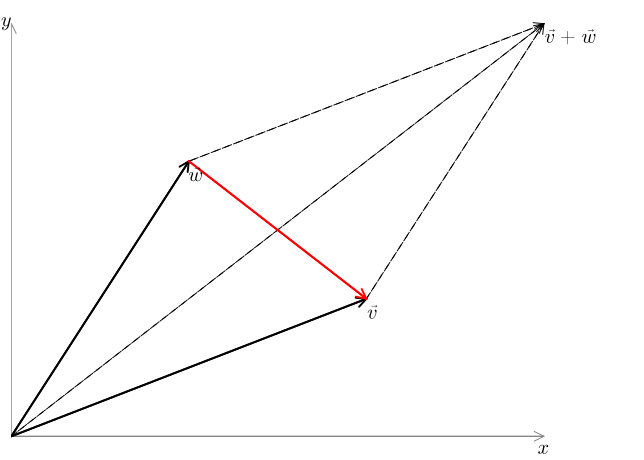

Figure 57.8: Parallelogram formed by two vectors $\vec{v}$ and $\vec{w}$. What is a description of red diagonal?

One diagonal is given by $\vec{v} + \vec{w}$. What is the other (as in the figure)?

\(\vec{v} \times \vec{w}\)

\(\vec{v} \cdot \vec{w}\)

\(\vec{v} + \vec{w}\)

\(\vec{v} - \vec{w}\)

What is the area of the parallelogram?

\(\vec{v} \cdot \vec{w}\)

\(\vec{v} + \vec{w}\)

\(\vec{v} - \vec{w}\)

\(\vec{v} \times \vec{w}\)

###### Question

The dot product of two vectors may be described in words: pair off the corresponding values, multiply them, then add. In `Julia` the `zip` command will pair off two iterable objects, like vectors, so it seems like this command: `sum(prod.(zip(u,v)))` will find a dot product. Investigate if it is does or doesn’t by testing the following command and comparing to the dot product:

```julia
u,v = [1,2,3], [5,4,2]
sum(prod.(zip(u,v)))
```

Does this return the same answer:

Yes

No

What does command `zip(u,v)` return?

A vector of values `[(1, 5), (2, 4), (3, 2)]`

An object of type `Base.Iterators.Zip` that is only realized when used

What does `prod.(zip(u,v))` return?

An object of type `Base.Iterators.Zip` that when realized will produce a vector of values

A vector of values `[5, 8, 6]`

###### Question

Let $\hat{u}$ and $\hat{v}$ be 3-dimensional **unit** vectors. What is the value of

$$(\hat{u} \times \hat{v}) \cdot (\hat{u} \times \hat{v}) + (\hat{u} \cdot \hat{v})^2?$$

\(1\)

Can't say in general

\(0\)

###### Question

Consider the projection of $\langle 1, 2, 3\rangle$ on $\langle 3, 2, 1\rangle$. What is its length?

###### Question

Let $\vec{u} = \langle 1, 2, 3 \rangle$ and $\vec{v} = \langle 3, 2, 1 \rangle$. Describe the plane created by these two non-parallel vectors going through the origin.

\(-4x + 8y - 4z = 0\)

\(x + 2y + z = 0\)

\(x + 2y + 3z = 6\)

###### Question

A plane $P_1$ is *orthogonal* to $\vec{n}_1$, a plane $P_2$ is *orthogonal* to $\vec{n}_2$. Explain why vector $\vec{v} = \vec{n}_1 \times \vec{n}_2$ is parallel to the *intersection* of $P_1$ and $P_2$.

\(\vec{v}\) is in plane \(P_1\), as it is orthogonal to \(\vec{n}_1\) and \(P_2\) as it is orthogonal to \(\vec{n}_2\), hence it is parallel to both planes.

\(\vec{n}_1\) and \(\vec{n_2}\) are unit vectors, so the cross product gives the projection, which must be orthogonal to each vector, hence in the intersection

###### Question

(From Strang). For an (analog) clock draw vectors from the center out to each of the 12 hours marked on the clock. What is the vector sum of these 12 vectors?

\(\langle 12, 12 \rangle\)

\(\vec{0}\)

\(12 \langle 1, 0 \rangle\)

If the vector to 3 o’clock is removed, (call this $\langle 1, 0 \rangle$) what expresses the sum of *all* the remaining vectors?

\(\langle 1, 0 \rangle\)

\(\langle 11, 11 \rangle\)

\(\langle -1, 0 \rangle\)

###### Question

Let $\vec{u}$ and $\vec{v}$ be unit vectors. Let $\vec{w} = \vec{u} + \vec{v}$. Then $\vec{u} \cdot \vec{w} = \vec{v} \cdot \vec{w}$. What is the value?

\(1 + \vec{u}\cdot\vec{v}\)

\(\vec{u} + \vec{v}\)

\(\vec{u}\cdot\vec{v} + \vec{v}\cdot \vec{v}\)

As the two are equal, which interpretation is true?

The vector \(\vec{w}\) must also be a unit vector

The angle they make with \(\vec{w}\) is the same

the two are orthogonal

###### Question

Suppose $\| \vec{u} + \vec{v} \|^2 = \|\vec{u}\|^2 + \|\vec{v}\|^2$. What is $\vec{u}\cdot\vec{v}$?

We have $(\vec{u} + \vec{v})\cdot(\vec{u} + \vec{v}) = \vec{u}\cdot \vec{u} + 2 \vec{u}\cdot\vec{v} + \vec{v}\cdot\vec{v}$. From this, we can infer that:

\(\vec{u}\cdot\vec{v} = -(\vec{u}\cdot\vec{u} \vec{v}\cdot\vec{v})\)

\(\vec{u}\cdot\vec{v} = 2\)

\(\vec{u}\cdot\vec{v} = 0\)

###### Question

In the figure, the tangent line to the unit circle for a given $\theta$ is given.

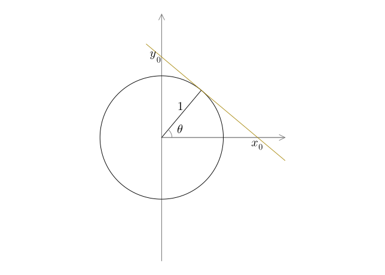

Using `SymPy`, find the values for $x_0$ and $y_0$.

For $x_0$, this value might be of use:

```julia
@syms s θ
r = [cos(θ), sin(θ)]
v = diff.(r, θ)
tl(s) = r .+ (s * v) # parametric description of the tangent line

sₓ = only(solve(last(tl(s))  ~ 0, s))
```

$- \tan{\left(θ \right)}$

(Simplify `tl(sₓ)`.)

What is the value of $x_0$?

\(\cos(\theta)\)

\(\frac{1}{\tan(\theta)}\)

\(-\tan(θ)\)

\(\frac{1}{\sin(\theta)}\)

\(\frac{1}{\cos(\theta)}\)

\(\sin(\theta)\)

What is the value of $y_0$?

\(\frac{1}{\sin(\theta)}\)

\(\sin(\theta)\)

\(\cos(\theta)\)

\(\frac{1}{\tan(\theta)}\)

\(\frac{1}{\cos(\theta)}\)

\(-\tan(θ)\)

###### Question

Give a geometric reason for this identity:

$$\vec{u} \cdot (\vec{v} \times \vec{w}) =
\vec{v} \cdot (\vec{w} \times \vec{u}) =
\vec{w} \cdot (\vec{u} \times \vec{v})$$

The vectors are all unit lengths, so these are all 1

The vectors are *orthogonal*, so these are all zero

The triple product describes a volume up to sign, this combination preserves the sign

###### Question

Snell’s law in planar form is $n_1\sin(\theta_1) = n_2\sin(\theta_2)$ where $n_i$ is a constant depending on the medium.

In vector form, we can express it using *unit* vectors through:

\(n_1 (\hat{v_1}\times\hat{N}) = n_2 (\hat{v_2}\times\hat{N})\)

\(n_1 (\hat{v_1}\times\hat{N}) = -n_2 (\hat{v_2}\times\hat{N})\)

###### Question

The Jacobi relationship show that for *any* $3$ randomly chosen vectors:

$$\vec{a}\times(\vec{b}\times\vec{c})+
\vec{b}\times(\vec{c}\times\vec{a})+
\vec{c}\times(\vec{a}\times\vec{b})$$

simplifies. To what? (Use `SymPy` or randomly generated vectors to see.)

\(\vec{0}\)

\(\vec{a}\)

\(\vec{a} + \vec{b} + \vec{c}\)